# Workshop Week 10

Author

Affiliation

STAT5003

School of Mathematics and Statistics

# 1 Learning Outcomes

**Learning Outcomes**

- Implement tree and ensemble methods
  1. Use `tree()` to apply decision tree models and evaluate model performance.
  2. Apply `ranger()` to implement random forests and evaluate hyperparameter impacts on model performance
  3. Utilise `gbm()` and `xgboost()` to build boosted models and analyse the model complexity and model performance.

# 2 Loading Packages

At the start of your R workshop, load all necessary packages to ensure a smooth session. Here’s an example:

```r
library(tidyverse)  # Data science packages
library(ggplot2)    # Data visualization
library(ggthemes)   # Inclusive ggplot themes
library(here)       # File paths
library(caret)
library(rsample)
library(tree)
library(ranger)
library(randomForest)
library(gbm)
library(xgboost)
```

The dataset we are using here is the wine quality dataset, containing information on several wines, and various qualities associated with those wines. Our primary outcome for this workshop will be the wine quality.

Load the `winequality-data.csv` data from the course Canvas website. Note that the last column is the ID of each sample and should be removed from further analysis.

```r
wine <- read.csv(here("datasets", "winequality-data.csv"), header = TRUE)
wine <- wine[, -ncol(wine)]
```

# 3 Decision Tree

**Train-Test Split**

Randomly split the full dataset into two equally sized sets: 50% for training (`wine.train`) and 50% for testing (`wine.test`).

The training set will be used to build the model, while the testing set will be used to evaluate the model’s performance on unseen data.

```r
set.seed(5003)

inTrain <- createDataPartition(wine[["quality"]], p = 0.5)[[1]]
wine.train <- wine[inTrain, ]
wine.test <- wine[-inTrain, ]

## Alternatively, using rsample package
##wine_split <- initial_split(wine, prop = 1/2)
##wine.train <- training(wine_split)
##wine.test <- testing(wine_split)
```

**Build decision tree model**

Build a decision tree model to predict wine `quality` using the 11 other features using the `tree()` function and visualize the results

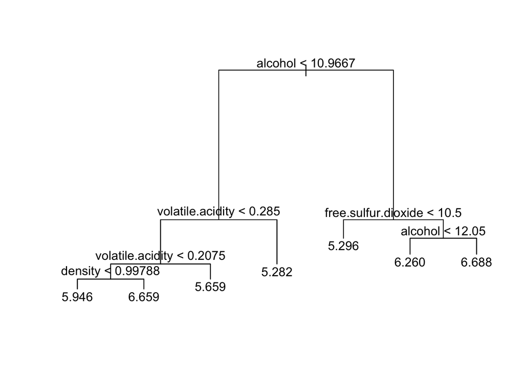

```r
set.seed(5003)
tree.model <- tree(quality ~ ., data = wine.train)
plot(tree.model)
text(tree.model)
```

**Assess decision tree model**

Use the single decision tree model to predict wine quality in the test set and calculate the residual sum of squares error.

```r
# Use the single decision tree to predict test data
tree.test <- predict(tree.model, newdata = wine.test)

# RSS - residual sum of squares
RSS <- sum((tree.test - wine.test$quality)^2)
# MSE - mean squared error
MSE <- mean((tree.test - wine.test$quality)^2)

print(RSS)
```

```
[1] 1115.128
```

```r
print(MSE)
```

```
[1] 0.5692333
```

# 4 Random Forest

**Fit Random Forest**

Implement a random forest classifier trained on the training data (`wine.train`) and use it to predict the test data.

```r
rf.model <- ranger(quality ~. , data = wine.train)
rf.test <- predict(rf.model, data = wine.test)
```

**Assess random forest**

Calculate the RSS on the test set prediction and compare it to the result of the single decision tree fitted above.

- Which model do you expect to have a smaller test RSS?
- Provide a brief justification for your answer based on your understanding of model flexibility, bias, and variance.

```r
RSS.rf <- sum((rf.test$predictions - wine.test$quality)^2)

# Test set RSS from random forest
print(RSS.rf)
```

```
[1] 838.9724
```

```r
## Compare it with the RSS calculated by the decision tree.
print(RSS)
```

```
[1] 1115.128
```

The random forest model has a lower test RSS. This is a single decision tree is highly flexible and can easily overfit the training data, leading to high variance and poor generalisation on unseen data. On the other hand, the RF builds $B$ boostrapped trees independently and aggregate the results. In addition, it further decorrelates the trees by randomly select a subset of the predictors at each split.

**Calibration**

There are two parameters to tune in the Random Forest model:

1. The number of trees to use (`ntree`in `randomForest` and `num.trees` in `ranger`)
2. The number of variables to consider at each split (`mtry` in both packages).

Use the default value for `mtry` = $\sqrt{p}$. Train random forests with different number of trees (e.g., different values for `num.tree` or `ntree` value on the training set. Evaluate the Residual Sum of Squares on the validation set and select the optimal tree number.

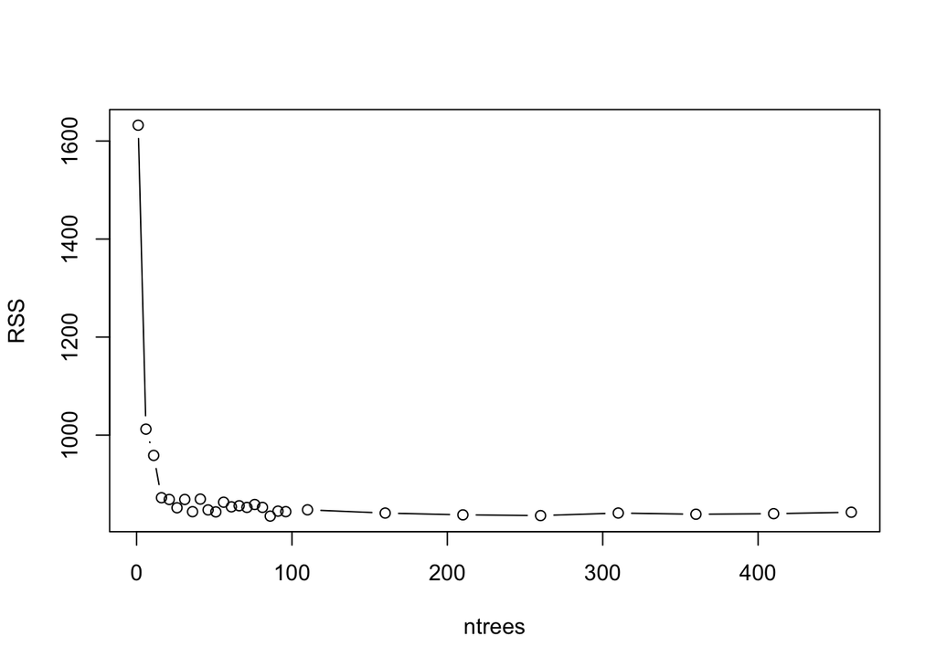

```r
set.seed(5003)

# Trying different values of ntree
RSS.test <- c()

ntree.seq <- c(seq(from = 1, to = 100, by = 5),
               seq(from = 110, to = 500, by = 50))

for(i in ntree.seq) {
  rf.model <- ranger(quality ~ ., data = wine.train, num.trees = i)
  rf.test <- predict(rf.model, data = wine.test)
  RSS.rf <- sum((rf.test$predictions - wine.test$quality)^2)
  RSS.test <- c(RSS.test, RSS.rf)
}

plot(ntree.seq, RSS.test, type = 'b', xlab = "ntrees", ylab = "RSS")
```

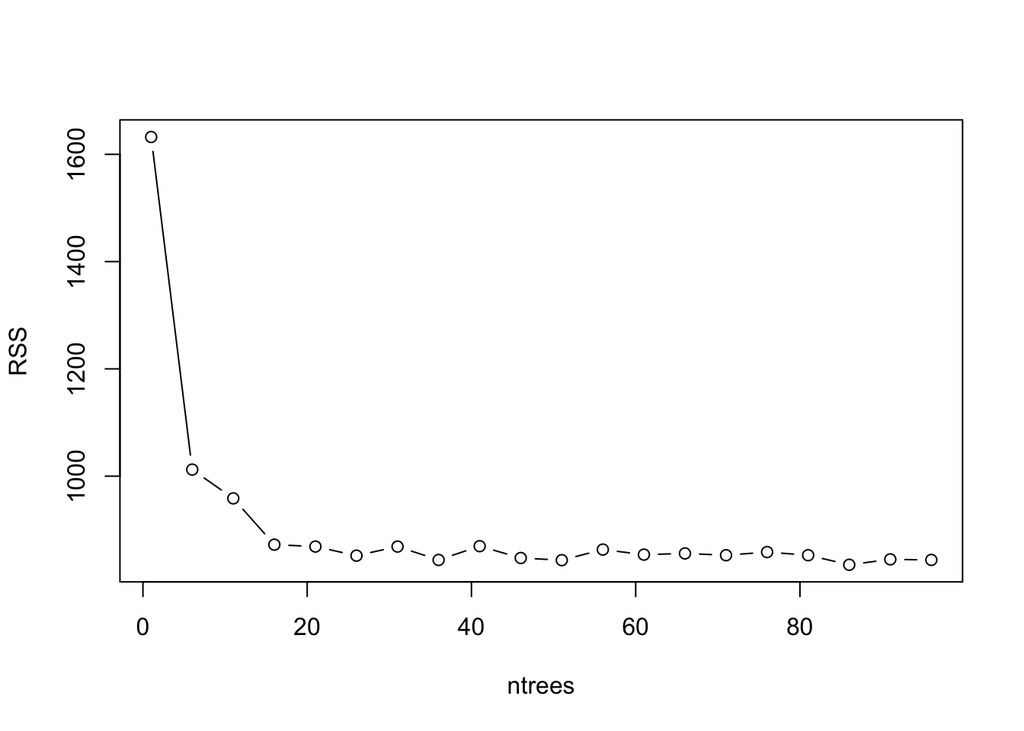

```r
## zoom-in

plot(ntree.seq[1:20], RSS.test[1:20], type = 'b', xlab = "ntrees", ylab = "RSS")
```

```r
## find the number of tree that has the lowest test RSS
which.min(RSS.test)
```

```
[1] 18
```

```r
ntree.seq[which.min(RSS.test)]
```

```
[1] 86
```

**Better Evaluation Strategy**

Can you suggest a better strategy for selecting the number of trees in a random forest? Briefly explain your reasoning.

A better strategy is to use k-fold cross-validation instead of a single train-validation split. Cross-validation:

- Reduces variance in the estimate of model performance
- Makes better use of available data
- Provides a more stable and reliable choice for the optimal number of trees

```r
# Parameters
k <- 5  # number of folds
ntree_vals <-ntree.seq # number of trees to try
results <- data.frame(tree = integer(), fold = integer(), rmse = numeric())

# 1. Create v-fold CV splits
set.seed(5003)
cv_splits <- vfold_cv(wine, v = k)

# 2. Loop over tree values
for (num_trees in ntree_vals) {

  # 3. Loop over folds
  for (i in seq_along(cv_splits$splits)) {

    # Training on 4 folds
    train_data <- analysis(cv_splits$splits[[i]])

    # Validation on 1 fold
    val_data <- assessment(cv_splits$splits[[i]])

    # Train model
    rf_model <- ranger(
      formula = quality ~ .,
      data = train_data,
      num.trees = num_trees,
      seed = 5003
    )

    # Predict on validation data
    preds <- predict(rf_model, data = val_data)$predictions

    # Compute RSS for the fold
    rss <- sum( (val_data$quality - preds)^2)


    # Store result
    results <- rbind(results, data.frame(tree = num_trees, fold = i, rss = rss))
  }
}

# 4. Average RMSE across folds for each tree setting
cv_summary <- results %>%
  group_by(tree) %>%
  summarise(cv_rmse = mean(rss), .groups = "drop")

print(cv_summary)
```

```
# A tibble: 28 × 2
    tree cv_rmse
   <dbl>   <dbl>
 1     1    676.
 2     6    371.
 3    11    346.
 4    16    338.
 5    21    335.
 6    26    330.
 7    31    329.
 8    36    327.
 9    41    323.
10    46    321.
# ℹ 18 more rows
```

# 5 Boosting

**gbm fitting**

Use the `gbm` package for this question. Implement a boosted tree model trained on `wine.train` and use it to predict the test data. What is the RSS on the test set prediction and how does it compare to the random forest model? Again, try different number of trees.

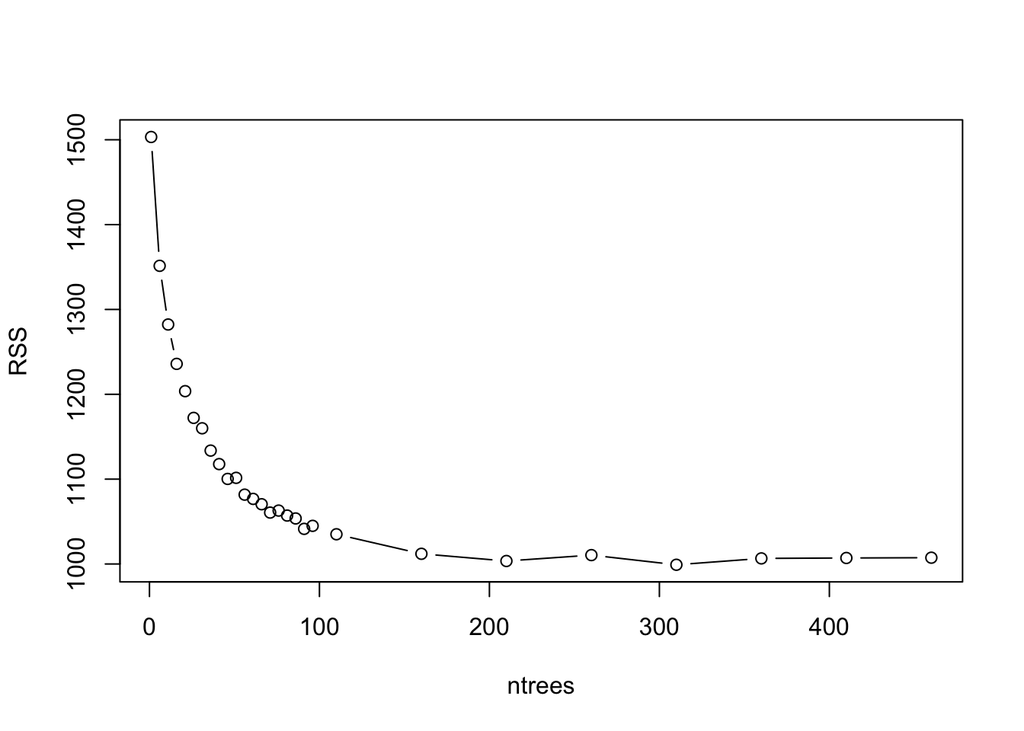

```r
set.seed(5003)
RSS.test.gbm <- c()
ntree.seq <- c(seq(from = 1, to = 100, by = 5),
               seq(from = 110, to = 500, by = 50))

for(i in ntree.seq) {
  gbm.model <- gbm(quality ~ ., data = wine.train,
   distribution = "gaussian", n.trees = i)
  gbm.test <- predict(gbm.model, newdata = wine.test, n.trees = i)
  RSS.gbm <- sum((gbm.test - wine.test$quality)^2)
  RSS.test.gbm <- c(RSS.test.gbm, RSS.gbm)
}


plot(ntree.seq, RSS.test.gbm, type = 'b', xlab = "ntrees", ylab = "RSS")
```

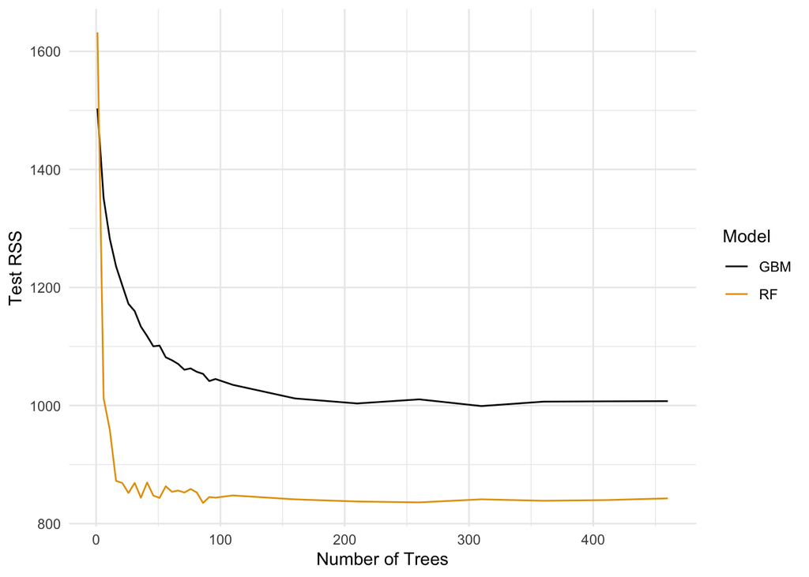

```r
## add random forest's results to this plot, via ggplot

df <- data.frame(ntree.seq, RSS.test.gbm, RSS.test)

# Comparison plot
ggplot(df, aes(x = ntree.seq)) +
  geom_line(aes(y = RSS.test.gbm, colour = "GBM")) +
  geom_line(aes(y = RSS.test, colour = "RF")) +
  labs(x = "Number of Trees", y = "Test RSS", colour = "Model") +
  theme_minimal() +
  scale_color_colorblind()
```

The RF has a lower test RSS than the GBM model.

**xgboost fitting**

Use the `xgboost` package for this question. Implement a boosted tree model trained on `wine.train` and use it to predict the test data.

1. Use `max_depth = 2` and plot the RSS for `nrounds = 300, 500, 1000, 1500` (different number of trees) and `eta = 0.01, 0.02, 0.03` (different learning rates).
2. Verify that a small value for `eta` is required for larger value of `nrounds`, and discuss with your peers why this is the case?

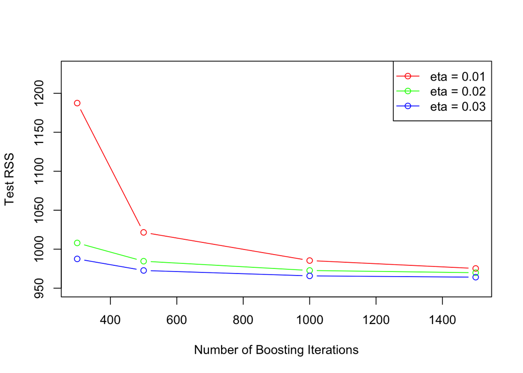

```r
set.seed(5003)

RSS.test.xgb <- matrix(0, nrow = 4, ncol = 3)
j = 1
for(eta in c(0.01, 0.02, 0.03)) {
    i = 1
    for(nrounds in c(300, 500, 1000, 1500)) {
    xgb.model <- xgboost(data = as.matrix(wine.train[, -12]),
                         label = wine.train[,12], nrounds = nrounds,
                         max_depth = 2, eta = eta, verbose = FALSE)
    xgb.test <- predict(xgb.model, newdata = as.matrix(wine.test[,-12]))
    RSS.xgb <- sum((xgb.test - wine.test$quality)^2)

    RSS.test.xgb[i, j] <- RSS.xgb
    i = i + 1
    }
    j <- j + 1
}

plot(x = c(300, 500, 1000, 1500), y = RSS.test.xgb[, 1], col = "red", type = "b", ylim = c(950, 1230),
     xlab = "Number of Boosting Iterations", ylab = "Test RSS")
points(x = c(300, 500, 1000, 1500), y = RSS.test.xgb[, 2], col = "green", type = "b")
points(x = c(300, 500, 1000, 1500), y = RSS.test.xgb[, 3], col = "blue", type = "b")
legend("topright", legend = paste0("eta = ", c(0.01, 0.02, 0.03)), col = c("red", "green", "blue"), lty = "solid", pch = 21)
```

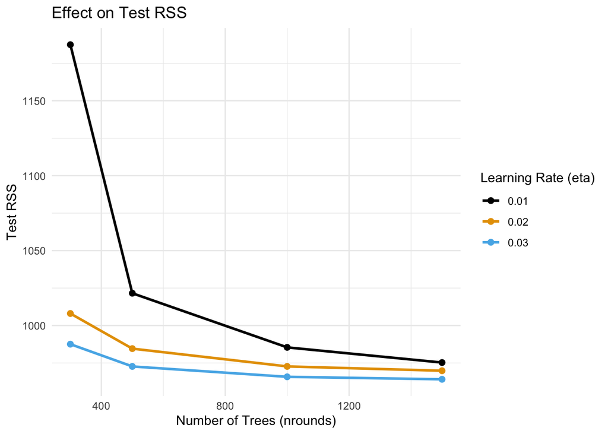

```r
## use ggplot
# Turn into a tidy dataframe
df_rss <- expand.grid(nrounds = c(300, 500, 1000, 1500), eta = c(0.01, 0.02, 0.03)) |>
  mutate(RSS = as.vector(RSS.test.xgb))

ggplot(df_rss, aes(x = nrounds, y = RSS, color = as.factor(eta))) +
  geom_line(size = 1) +
  geom_point(size = 2) +
  labs(x = "Number of Trees (nrounds)",
       y = "Test RSS",
       color = "Learning Rate (eta)",
       title = "Effect on Test RSS") +
  theme_minimal() +
  scale_color_colorblind()
```

In summary:

Boosting works by adding trees sequentially to correct the residuals of previous trees.

The learning rate (eta) controls how much each individual tree contributes to the model.

- A small eta means each tree moves the prediction just a little bit toward the correct value. To achieve a good accuracy, you need many small steps and thus increases the number of trees (nrounds).
- A large eta means each tree moves the prediction a lot at each step. Therefore, fewer steps needed to fit the training data. However, it is at risk of overfitting if the steps are too large (aggressive).